# ceo_request slides

> Should Olist remove underperforming sellers from its marketplace?

## Problem statement

- The `revenues` it brings
- The `costs` associated with all its bad reviews
- The resulting `profits` (revenues - costs)

**review_score ------> cost (BRL)**

- 1 star ------> 100
- 2 stars ------> 50
- 3 stars ------> 40
- 4 stars ------> 0
- 5 stars ------> 0

Solution : We suggest to not remove underperforming sellers from its marketplace, but to increase price rate to 15%

#### The revenues for all sellers and per seller

```python
# Import olist seller
from olist.seller import Seller
seller=Seller(); sellers=seller.get_training_data()
```

```python
mask_columns = [ 'seller_id', 'date_first_sale', 'date_last_sale', 'sales' , 'n_orders']
sellers_1 = sellers[mask_columns].copy()
sellers_1.head(2)
```

|  | seller_id | date_first_sale | date_last_sale | sales | n_orders |
| --- | --- | --- | --- | --- | --- |
| 0 | 3442f8959a84dea7ee197c632cb2df15 | 2017-05-05 16:25:11 | 2017-08-30 12:50:19 | 218.70 | 3 |
| 1 | d1b65fc7debc3361ea86b5f14c68d2e2 | 2017-03-29 02:10:34 | 2018-06-06 20:15:21 | 11703.07 | 40 |

```python
sellers_1['active_months'] = \
          (sellers_1['date_last_sale'] - sellers_1['date_first_sale']) / np.timedelta64(1,'M')
sellers_1['revenues'] = sellers_1['sales'].map(lambda x : .1*x) \
                       + sellers_1['active_months']*80
sellers_1.head(2)
```

|  | seller_id | date_first_sale | date_last_sale | sales | n_orders | active_months | revenues |
| --- | --- | --- | --- | --- | --- | --- | --- |
| 0 | 3442f8959a84dea7ee197c632cb2df15 | 2017-05-05 16:25:11 | 2017-08-30 12:50:19 | 218.70 | 3 | 3.839119 | 328.999525 |
| 1 | d1b65fc7debc3361ea86b5f14c68d2e2 | 2017-03-29 02:10:34 | 2018-06-06 20:15:21 | 11703.07 | 40 | 14.283770 | 2313.008599 |

```python
print("Revenues for all sellers :", round(total_revenues, 2))
```

```
Revenues for all sellers : 2787744.21
```

##### Result : revenues per seller

Total revenues for all sellers: 2_787_744 BRL

```python
round( sellers_1[['seller_id', 'revenues']] , 2) \
                        .sort_values(by = 'revenues') \
                        .head(3)
```

|  | seller_id | revenues |
| --- | --- | --- |
| 2241 | 77128dec4bec4878c37ab7d6169d6f26 | 0.65 |
| 2016 | 1fa2d3def6adfa70e58c276bb64fe5bb | 0.69 |
| 2314 | 702835e4b785b67a084280efca355756 | 0.76 |

```python
round( sellers_1[['seller_id', 'revenues']] , 2 ) \
                        .sort_values(by = 'revenues') \
                        .tail(3)
```

|  | seller_id | revenues |
| --- | --- | --- |
| 2360 | 4a3ca9315b744ce9f8e9374361493884 | 21613.96 |
| 868 | 53243585a1d6dc2643021fd1853d8905 | 23218.33 |
| 2506 | 4869f7a5dfa277a7dca6462dcf3b52b2 | 24354.20 |

#### Total costs - bad reviews

```python
# Merging  matching_table  and  orders_1   tables

costs = matching_table[['order_id','seller_id']] \
                      .merge( orders_1 , on = 'order_id')
costs.head(3)
```

|  | order_id | seller_id | review_score |
| --- | --- | --- | --- |
| 0 | e481f51cbdc54678b7cc49136f2d6af7 | 3504c0cb71d7fa48d967e0e4c94d59d9 | 4 |
| 1 | 53cdb2fc8bc7dce0b6741e2150273451 | 289cdb325fb7e7f891c38608bf9e0962 | 4 |
| 2 | 47770eb9100c2d0c44946d9cf07ec65d | 4869f7a5dfa277a7dca6462dcf3b52b2 | 5 |

```python
costs['costs'] = costs['review_score'].map(review_to_price)
costs_1 = costs[['seller_id', 'costs']].copy()  # , 'review_score'
costs_1.tail(3)
```

|  | seller_id | costs |
| --- | --- | --- |
| 112151 | a1043bafd471dff536d0c462352beb48 | 50 |
| 112152 | a1043bafd471dff536d0c462352beb48 | 50 |
| 112153 | ececbfcff9804a2d6b40f589df8eef2b | 0 |

Costs for all sellers: 1_894_610 BRL

#### Costs per seller - "bad reviewes"

```python
olist_costs = costs_1.groupby('seller_id').sum().reset_index()

olist_costs.sort_values(by = 'costs') .head(3)
```

|  | seller_id | costs |
| --- | --- | --- |
| 1484 | 7cf4ea70955b00d6b3c22542598e2715 | 0 |
| 869 | 4b90495391ac0bd181a80a459df1e718 | 0 |
| 2065 | b2eecf5ea250510da76590ca79d60e5d | 0 |

```python
olist_costs.sort_values(by = 'costs') .tail(3)
```

|  | seller_id | costs |
| --- | --- | --- |
| 1190 | 6560211a19b47992c3666cc44a7e94c0 | 38660 |
| 1480 | 7c67e1448b00f6e969d365cea6b010ab | 44350 |
| 858 | 4a3ca9315b744ce9f8e9374361493884 | 45160 |

#### The total resulting `profits` (revenues - costs)

```python
print( " Total Revenues : ", round(total_revenues, 2))
print( " Total Costs : ", round(total_costs, 2))

profits =  total_revenues - total_costs
print( " The total resulting profits : ", round(profits, 2))
```

```
 Total Revenues :  2787744.21
 Total Costs :  1894610
 The total resulting profits :  893134.21
```

#### The resulting profits per seller :

```python
profits_seller = sellers_1.merge(olist_costs, on = 'seller_id')

# we only keep the columns of interest
profits_seller = profits_seller[ ['seller_id',
                                  'n_orders', 'revenues',
                                  'costs' , 'active_months' , 'sales' ] ]

# we create a new column profits
profits_seller['profits'] = profits_seller['revenues'] - profits_seller['costs']
```

```python
round( profits_seller, 2) .sort_values(by = 'profits') .head(2)
```

|  | seller_id | n_orders | revenues | costs | active_months | sales | profits |
| --- | --- | --- | --- | --- | --- | --- | --- |
| 453 | 1f50f920176fa81dab994f9023523100 | 1404 | 12037.63 | 38340 | 16.80 | 106939.21 | -26302.37 |
| 769 | 6560211a19b47992c3666cc44a7e94c0 | 1854 | 13797.31 | 38660 | 18.34 | 123304.83 | -24862.69 |

```python
round( profits_seller, 2) .sort_values(by = 'profits').tail(2)
```

|  | seller_id | n_orders | revenues | costs | active_months | sales | profits |
| --- | --- | --- | --- | --- | --- | --- | --- |
| 67 | 7e93a43ef30c4f03f38b393420bc753a | 336 | 19337.85 | 3360 | 21.18 | 176431.87 | 15977.85 |
| 868 | 53243585a1d6dc2643021fd1853d8905 | 358 | 23218.33 | 5450 | 11.76 | 222776.05 | 17768.33 |

#### Profits incl. IT costs

```python
#The IT department also told you that since the birth of the marketplace,
#cumulated IT costs have amounted to 500,000 BRL.

IT_costs = 500_000
print("The final resulting profits : ",  round(profits - IT_costs, 2))
```

```
The final resulting profits :  393134.21
```

### Recap

- Recap :
  - Revenues : 2_787_744 BRL
  - Costs "bad reviews" : 1_894_610 BRL
  - The resulting profits for all sellers : 893_134 BRL
  - IT_costs : 500_000 BRL
  - The final resulting profits : 393_134 BRL

#### The number of orders

```python
sellers_2 = profits_seller.merge(olist_costs,
                            on = 'seller_id')
```

```python
sellers_3 = sellers_2.merge( sellers[[ 'seller_id', 'review_score']])
```

```python
sellers_3["Rank_profits"] = sellers_3["profits"].rank()
sellers_3.sort_values(by = 'n_orders', ascending = False).head(3)
```

[output not shown]

```python
print( " the total cumulated number of orders approved. : ", sellers_3['n_orders'].sum() )
```

```
 the total cumulated number of orders approved. :  99844
```

##### The number of orders vs. profits

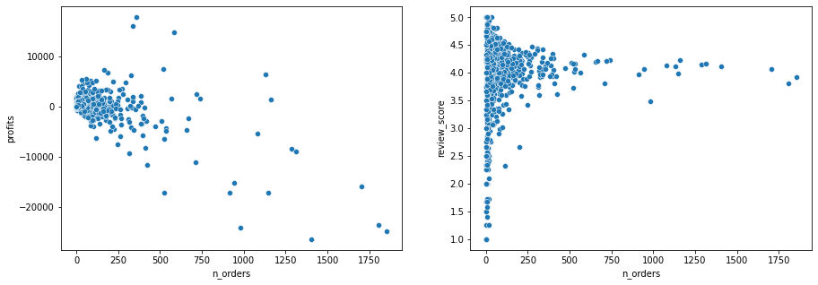

```python
fig,axes=plt.subplots(1,2, figsize=(15,5))
sns.scatterplot(x='n_orders', y='profits', data=sellers_3 ,ax=axes[0])
sns.scatterplot(x='n_orders', y='review_score', data=sellers_3, ax=axes[1]);
```

## Desicion_for_sellers

```python
sellers_1.head(2)
```

|  | seller_id | date_first_sale | date_last_sale | sales | n_orders | active_months | revenues |
| --- | --- | --- | --- | --- | --- | --- | --- |
| 0 | 3442f8959a84dea7ee197c632cb2df15 | 2017-05-05 16:25:11 | 2017-08-30 12:50:19 | 218.70 | 3 | 3.839119 | 328.999525 |
| 1 | d1b65fc7debc3361ea86b5f14c68d2e2 | 2017-03-29 02:10:34 | 2018-06-06 20:15:21 | 11703.07 | 40 | 14.283770 | 2313.008599 |

```python
sellers_rate_price = sellers_1. copy()

sellers_rate_price['active_months'] = \
          (sellers_rate_price['date_last_sale'] - sellers_rate_price['date_first_sale']) \
                  / np.timedelta64(1,'M')

sellers_rate_price['revenues'] = sellers_rate_price['sales'].map(lambda x : .15*x) \
                       + sellers_rate_price['active_months']*80

total_revenues_rate_price = sellers_rate_price['revenues'].sum()

total_costs = olist_costs['costs'].sum() # remaining costs
profits_rate_price =  total_revenues_rate_price - total_costs

IT_costs = 500_000
```

```python
print("Revenues for all sellers 15%:", total_revenues_rate_price)
print( " The total resulting profits 15%: ", round(profits_rate_price, 2))
print("The final resulting profits 15%: ",  round(profits_rate_price - IT_costs, 2))
```

```
Revenues for all sellers 15%: 3465871.8262827117
 The total resulting profits 15%:  1571261.83
The final resulting profits 15%:  1071261.83
```

```python
print("Revenues for all sellers 10%:", total_revenues)
print( " The total resulting profits 10%: ", round(profits, 2))
print("The final resulting profits 10%: ",  round(profits - IT_costs, 2))
```

[output not shown]

### Recap

- Recap :
  - IT_costs : *500_000 BRL*
  - Costs "bad reviews" : *1_894_610 BRL*
  - Revenues (10%): 2_787_744 BRL
    - Revenues (15%): 3_465_871 BRL
  - The resulting profits for all sellers (10%): 893_134 BRL
    - The resulting profits for all sellers (15%): 1_571_261 BRL
  - The final resulting profits (incl. ,IT 10%): 393_134 BRL
    - The final resulting profits (incl. ,IT 15%): 1_071_261 BRL

```python
product_price = [ 10, 20, 200]
n_orders = 3
review_scores =  [ 3, 5, 1]   #----> #average(review_score) = 3

cost_ex = 40 + 0 + 100
costs_ex = 140
revenues_ex = sum([ 1,  2, 20])
revenues_ex = 23
profits = 23 - 140
profits = -117
```

```python
product_price = [ 10, 20, 200]
n_orders = 3
review_scores =  [ 3, 4, 2]   #----> #average(review_score) = 3

cost_ex = 3*40  + 0 + 2*50
costs_ex = 220
revenues_ex = sum([ 1,  2, 20])
revenues_ex = 23
profits = 23 - 220
profits = -197
```

```python
product_price = [ 10, 20, 20]
n_orders = 3
review_scores =  [ 3, 4, 2]  # -----> #average(review_score) = 5

cost_ex = 3*40  + 0 + 2*50
costs_ex = 220

revenues_ex = sum([ 3,  2, 2])
revenues_ex = 7 - 220
profits = -213
```

```python
product_price = [ 30, 40, 50]
n_orders = 3
review_scores =  [ 5, 5, 5]  # -----> #average(review_score) = 5

cost_ex = 0
revenues_ex = sum([ 3,  4, 5])
revenues_ex = 12 - 0
profits = 12
```